# Black Assault death trends analysis

## HP filter-based models

We will turn to filter-based models, which separate values over time into cycle and trend components. The smoothing parameters used in the filter affect the values of both components, and so two different smoothing parameters will be considered, 6.25 and 100.00.

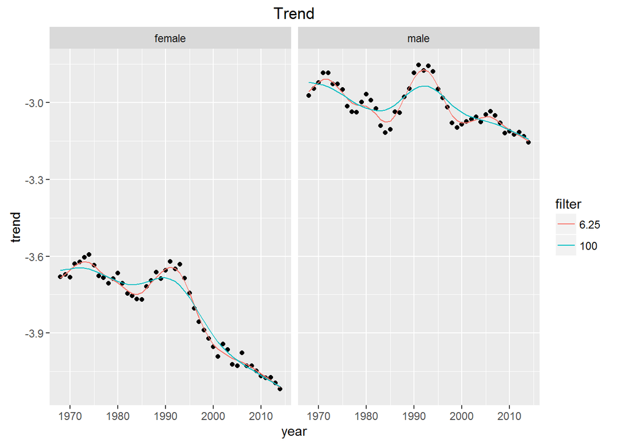

```r
# Exercise 2.2 ------------------------------------------------------------

# E2. Detrend y using the Hodrick-Prescott (HP) filter (there should be a R package that does that).
# There are two conventional values for the smoothing parameter  for annual data: 6.25 and 100.
# Please use both since they usually do vary the detrending a lot.
# Once you detrended y using HP, then run equation 3, where res_y will be the
# detrended values of y using HP, and plot the fitted values.

# Need to first convert the data to a timeseries format

# actually two separate dataseries - one for males and one for females

fn <- function(x){
  y <- data.frame(year = as.Date(as.character(x$year), format = "%Y"), value = x$death_rate)
  output <- xts(y$value, y$year)
  return(output)
}

dta_list <- dta_subset %>%
  mutate(death_rate = death_count / population_count) %>%
  mutate(death_rate = log(death_rate, 10)) %>%
  dlply(., .(sex), fn)


dta_list_detrended_100 <- llply(dta_list, hpfilter, freq = 100)
dta_list_detrended_6_25 <- llply(dta_list, hpfilter, freq = 6.25)



fn2 <- function(x){
  md_part <- paste0("-", str_split(today(), "\\-", n = 2)[[1]][[2]]) # the filter above adds the month and the day to years,
  # this needs to be removed using the lines above (from lubridate) and below
  year <- dimnames(x$trend)[1][[1]]  %>% str_replace_all(., md_part, "")  %>% as.numeric()
  output <- data.frame(year = year, cycle = x$cycle, trend = x$trend[,1])
  return(output)
}


dta_df_detrended_100 <- ldply(dta_list_detrended_100, fn2) %>%
  tbl_df %>% rename(sex = .id)

dta_df_detrended_6_25 <- ldply(dta_list_detrended_6_25, fn2) %>%
  tbl_df %>% rename(sex = .id)




dta_df_detrended_100 <- dta_subset  %>%
  select(year, rep)  %>%
  distinct %>%
  right_join(dta_df_detrended_100)
dta_df_detrended_6_25 <- dta_subset  %>%
  select(year, rep)  %>%
  distinct %>%
  right_join(dta_df_detrended_6_25)
dta_df_detrended_100 <- dta_df_detrended_100 %>% mutate(filter = 100)
dta_df_detrended_6_25 <- dta_df_detrended_6_25 %>% mutate(filter = 6.25)



dta_df_detrended <- bind_rows(dta_df_detrended_100, dta_df_detrended_6_25)
dta_df_detrended <- dta_df_detrended %>%
  left_join(simple) %>%
  select( -year2) %>%
  rename(actual = lg10mr) %>%
  mutate(filter = factor(filter))
dta_df_detrended %>%
  ggplot(., aes(x = year)) +
  geom_point(aes(y = actual)) +
  geom_line(aes(y = trend, colour = filter, group = filter)) +
  facet_wrap(~ sex) +
  labs(y = "trend", title = "Trend")
```

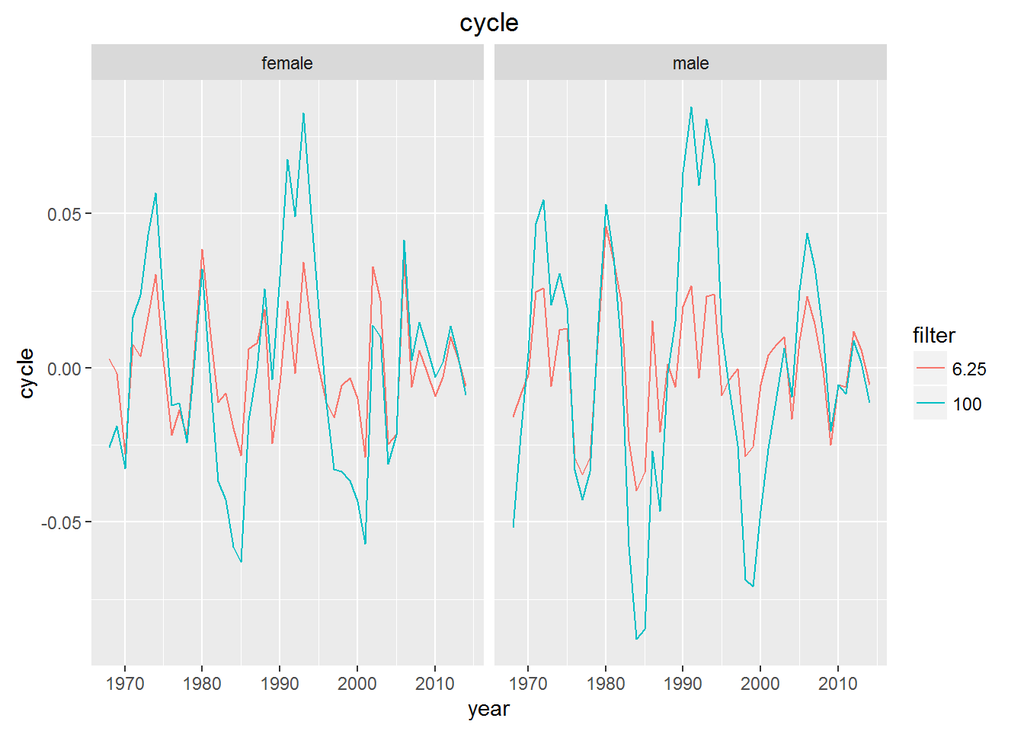

```r
dta_df_detrended %>%
  ggplot(., aes(x = year)) +
  geom_line(aes(y = cycle, colour = filter, group = filter)) +
  facet_wrap(~ sex) +
  labs(y = "cycle", title = "cycle")
```

Of the two variants of the model, the parameter 6.25 appears to provide a much closer fit, even though it does not appear to be as close as a 12th order polynomial.

We will now consider the relationship between cycle and rep

```r
dta_df_detrended  %>% filter(sex == "female", filter == 100)  %>% lm(cycle ~ rep, .)  %>% summary
```

```
##
## Call:
## lm(formula = cycle ~ rep, data = .)
##
## Residuals:
##      Min       1Q   Median       3Q      Max
## -0.06912 -0.02343  0.00048  0.01848  0.07643
##
## Coefficients:
##              Estimate Std. Error t value Pr(>|t|)
## (Intercept)  0.006223   0.006268   0.993    0.326
## rep         -0.015395   0.009858  -1.562    0.125
##
## Residual standard error: 0.03316 on 45 degrees of freedom
## Multiple R-squared:  0.05141,    Adjusted R-squared:  0.03033
## F-statistic: 2.439 on 1 and 45 DF,  p-value: 0.1254
```

```r
dta_df_detrended  %>% filter(sex == "male", filter == 100)  %>% lm(cycle ~ rep, .)  %>% summary
```

```
##
## Call:
## lm(formula = cycle ~ rep, data = .)
##
## Residuals:
##       Min        1Q    Median        3Q       Max
## -0.094622 -0.025577  0.001311  0.024168  0.078109
##
## Coefficients:
##              Estimate Std. Error t value Pr(>|t|)
## (Intercept)  0.006613   0.008002   0.826    0.413
## rep         -0.016359   0.012586  -1.300    0.200
##
## Residual standard error: 0.04234 on 45 degrees of freedom
## Multiple R-squared:  0.03619,    Adjusted R-squared:  0.01477
## F-statistic:  1.69 on 1 and 45 DF,  p-value: 0.2003
```

```r
dta_df_detrended  %>% filter(sex == "female", filter == 6.25)  %>% lm(cycle ~ rep, .)  %>% summary
```

```
##
## Call:
## lm(formula = cycle ~ rep, data = .)
##
## Residuals:
##       Min        1Q    Median        3Q       Max
## -0.029438 -0.010910 -0.001459  0.009451  0.040256
##
## Coefficients:
##              Estimate Std. Error t value Pr(>|t|)
## (Intercept)  0.001111   0.003414   0.325    0.746
## rep         -0.002749   0.005369  -0.512    0.611
##
## Residual standard error: 0.01806 on 45 degrees of freedom
## Multiple R-squared:  0.00579,    Adjusted R-squared:  -0.0163
## F-statistic: 0.2621 on 1 and 45 DF,  p-value: 0.6112
```

```r
dta_df_detrended  %>% filter(sex == "male", filter == 6.25)  %>% lm(cycle ~ rep, .)  %>% summary
```

```
##
## Call:
## lm(formula = cycle ~ rep, data = .)
##
## Residuals:
##       Min        1Q    Median        3Q       Max
## -0.040060 -0.012184 -0.000859  0.013419  0.046210
##
## Coefficients:
##               Estimate Std. Error t value Pr(>|t|)
## (Intercept)  0.0001775  0.0038605   0.046    0.964
## rep         -0.0004390  0.0060719  -0.072    0.943
##
## Residual standard error: 0.02043 on 45 degrees of freedom
## Multiple R-squared:  0.0001161,  Adjusted R-squared:  -0.0221
## F-statistic: 0.005227 on 1 and 45 DF,  p-value: 0.9427
```

In each of the above regressions the coefficient on rep is negative, which seems to be the ‘wrong’ direction (i.e. lower when reps in office). However in no case, for either sex or for either filter, is the coefficient on rep statistically significant.

## Suggestions for additional analysis

- More systematically explore the effect of other filter values
- Try to extract something like AIC or BIC if possible for different filter-based models
- Add more terms to model predicting cycle, for example socioeconomic variables